# Inhale, Exhale, Analyze: BMI’s Imprint on Impulse Oscillometry Outcomes

Joshua J. Cook, M.S., ACRP-PM, CCRC, Syed Ahzaz H. Shah, B.S., Jacob Hernandez, B.S., Sara Basili, M.S.

2024-04-13

# **Linear Mixed Models (LMMs)**

- Data structures & use cases
- Fixed v. random effects
- Strengths/weaknesses
- Implementation Methods

# **Methods - Mathematical Foundations**

## Linear Algebra

LMMs leverage linear algebra and in our case, we are explaining the mathematical concepts for a two-level longitudinal random intercepts model. Index i is used to denote the participant and index t is used to denote the different time points of the observation

$$Y=X\beta + Zu+ \epsilon$$

- Y is the response vector. Shape N x 1 where N is the number of the number of repeated measures
- X is the design matrix for fixed effects. Shape N x p where p is the number of regression coefficients
- β is the vector of regression coefficients. Shape P x 1
- Z is the design matrix for random effects. Shape N x J where J number of subjects
- *u* is the vector of random effects. Shape J x 1 vector
- ϵ is the vector of residual errors. Shape N x 1 vector

## Assumptions

1. The relationship between the predictors and response variable is assumed to be linear, within each level of random effects.
2. Random effects (*u*) are assumed to follow a normal distribution with mean zero and variance-covariance matrix G.

   $\gamma \sim N(0,G)$
3. Residual errors (ϵ ) are assumed to follow a normal distribution with mean zero and variance-covariance matrix R.

   $\epsilon \sim N(0,R)$
4. Random effects (*u*) and residual errors (ϵ ) are assumed to be independent.
5. Homoscedasticity is assumed for the residuals across all levels of the independent variables.

## Implementation in R

- Data is loaded from a CSV file using the read.csv function
- Fitting Data to LMMs
  - The lme() function from the `nlme` package has parameters to specify random effects structure and estimation method.
  - lmer() function from the `lme4` package has similar syntax to the lme() function but differs in how it handles random effects specifications
- Hypothesis Testing
  - Evaluated using F-tests, Likelihood ratio test, and Shapiro-Wilks tests

# **The Capstone Project**

## Dataset Overview

- Key attributes and measurements in the dataset
- Categorical and numerical variables
- Presence of missing values, especially in the Fres_PP variable

## Why Linear Mixed Models (LMMs)?

- Suitability of LMMs for the dataset
- Multiple observations over time for the same participants
- Handling unbalanced groups, as observed in participant dropout over time

## Linear Mixed Model Approach

- Variable of interest (BMI) and controlled variables (fixed effects)
- Random variability between individual observations (random effects)
- Incorporation of random effects in the final model

# **Results**

## The Initial Model

In this dataset:

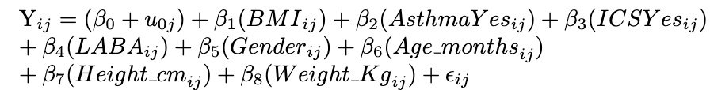

Equation 2. The initial LMM.

## Implementation

```r
#lme()

# Fit models using a tidy and clear approach
model_lme <- lme(
  fixed = cbind(R5Hz_PP, R20Hz_PP, X5Hz_PP, Fres_PP) ~ BMI + Asthma + ICS + LABA + Gender + Age_months + Height_cm + Weight_Kg,
  random = list(Subject_ID = pdIdent(~1)),
  data = x_clean,
  method = "REML"
)

#lmer()

model_lmer <- lmer(
  formula = R5Hz_PP + R20Hz_PP + X5Hz_PP + Fres_PP ~ BMI + Asthma + ICS + LABA + Gender + Age_months + Height_cm + Weight_Kg + (1 | Subject_ID),
  data = x_clean
)
```

## The Imputed Model

- Upon further inspection, outliers were present in most variables. To improve model performance, these outliers were imputed using the threshold values.
- Confirmation of outlier removal was completed using boxplots.
- All metrics were then reevaluated.

## The Final Model

This was a longitudinal study involving multiple observations for each subject over time, and subjects are grouped into two categories (children with sickle cell disease and African-American children with asthma).

Thus, in this final model:

- we modeled **`Group`** as a *fixed effect* since we were interested in the effect of the group itself on the outcome.
- **`Subject_ID`** should be a *random effect* to account for the repeated measures within subjects.
- **`Observation_number`** was included as a *random slope* within **`Subject_ID`** (i.e., nested within Subject_ID).
- The same visualizations and tests were completed to assess the LMM assumptions.

## The Final Model

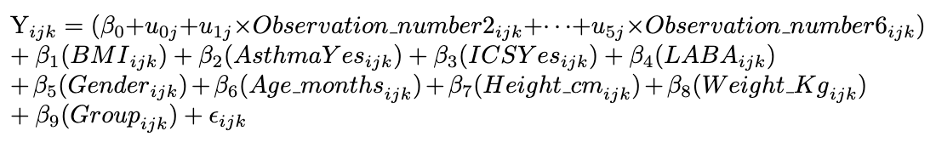

Equation 3. The final LMM.

## Implementation

```r
model_lme_imputed_final <- lme(fixed = cbind(R5Hz_PP, R20Hz_PP, X5Hz_PP, Fres_PP) ~ BMI + Asthma + ICS + LABA + Gender + Age_months + Height_cm + Weight_Kg + Group,
                         data = x_clean_imputed,
                         random = list(Subject_ID = pdIdent(~1 + Observation_number)),
                         method = "REML")
```

# **Conclusion**